# Most excellent figures in R with ggplot2

Ben Williams

February 21, 2016

# 1 Short version

Set up the R work environment to produce publication quality documents using ggplot. Use theme_set to define the base figure elements - in this case: no gridlines, a white background, and 12 pt times new roman font.

Load packages

```r
library(extrafont)
#font_import() only do this one time - it takes a while
loadfonts(device="win")
windowsFonts(Times=windowsFont("TT Times New Roman"))

library(ggplot2)
theme_set(theme_bw(base_size=12,base_family='Times New Roman')+
  theme(panel.grid.major = element_blank(),
  panel.grid.minor = element_blank()))
```

Use ggsave to increase dpi from base R level (72 dpi) and to defining figure dimensions.

```r
ggplot(data, aes(x=x, y=y))+geom_point()
ggsave("filename.png", dpi=300, height=4, width=5, units="in")
```

# 2 Basics

## 2.1 ggplot base figures

You say you want to create a publication quality figure using ggplot? Well then, you are in the right place!  
First, let’s look at what ggplot produces as a base graphic. We will use the R built in data set *mtcars*.

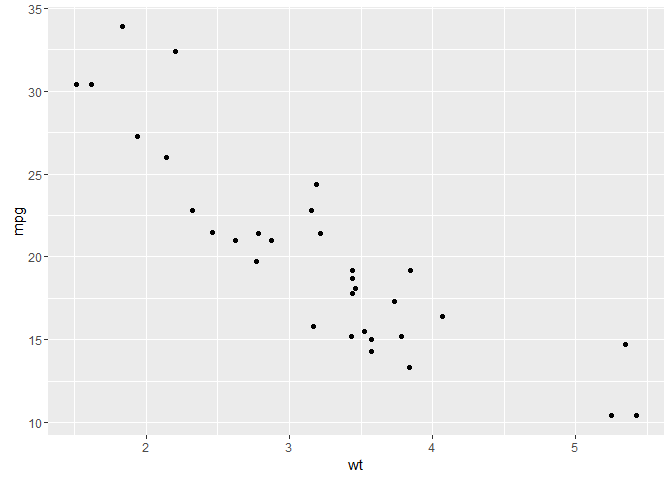

Figure 1. Base plot.

```r
library(ggplot2)
ggplot(mtcars, aes(wt, mpg))+geom_point()
```

We get a gray background with small black dots, white grid lines, and a font that is not particularly legible when the figure is placed in this document. Most journals require a figure to be 300 dpi or greater not to mention the background should be white, without grid lines, and with a font that is consistent with the rest of the manuscript. Lets address these step by step.

## 2.2 White background

Want a white background? We’ve got that. Simply add a *theme* to the figure. In this case we will add *theme_bw()*.

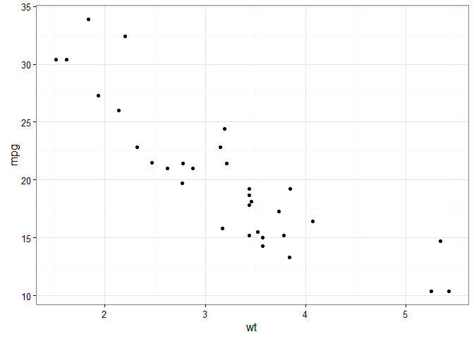

Figure 1b. White background.

```r
ggplot(mtcars, aes(wt, mpg))+geom_point()+theme_bw()
```

## 2.3 Remove grid lines

To remove gridlines add another *theme*, and use element_blank() to clear the lines.

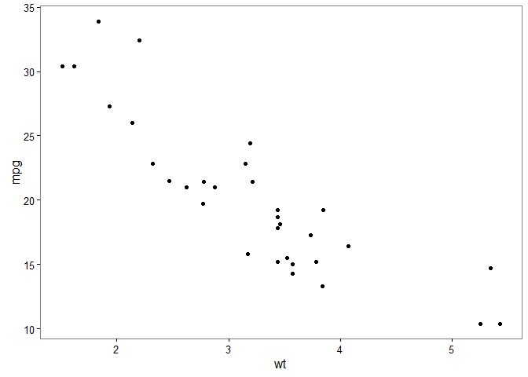

Figure 1c. White background, no gridlines.

```r
ggplot(mtcars, aes(wt, mpg))+geom_point()+
   theme_bw()+
   theme(panel.grid.major = element_blank(),
         panel.grid.minor = element_blank())
```

## 2.4 Fonts and resolution

Fonts are both easy and not so easy to deal with depending on what your needs are.  
In this case we want a Times New Roman 12 pt font. The 12 pt is easy so let’s start with that. Simply add a base size option in theme bw()

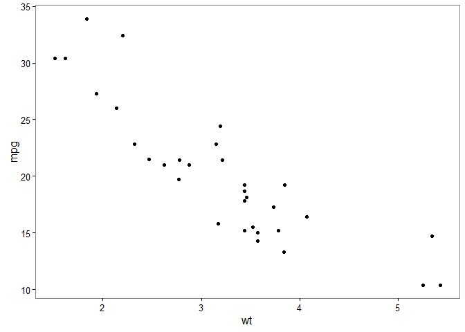

Fig 2. White background, no gridlines, plus a font size change.

```r
ggplot(mtcars, aes(wt, mpg))+geom_point()+
   theme_bw(base_size = 12)+
   theme(panel.grid.major = element_blank(),
         panel.grid.minor = element_blank())
```

Hey nothing happened, Figure 2 is the same as Figure 1c?  
The reason for this is the file size. These figures would be saved as .png and R has a base figure output of 72 ppi. This resolution is too low for journal submissions so let’s up it. In this case I’m outputting a .png file with a set width and height and a resolution of 300.

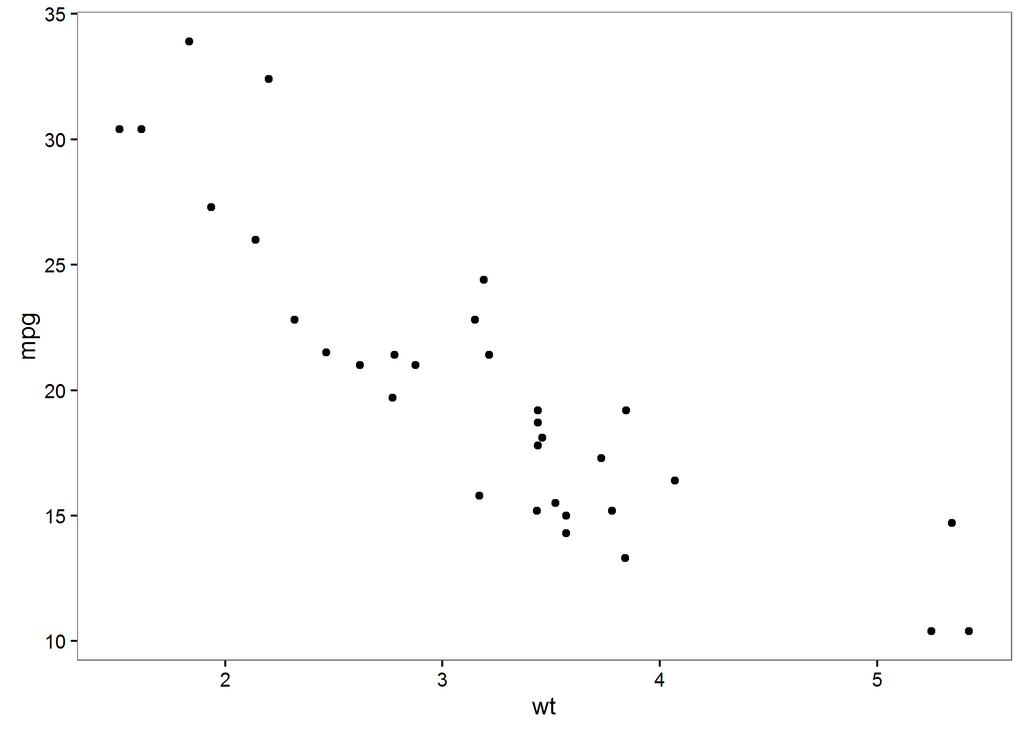

Fig 2b. Changed font size and resolution.

In order to save the figure we will use ggsave. (Note the size increase of Figure 2b is due to presenting this on the web at 300 dpi - the ggsave function shown below will save a figure in a specified format at a chosen resolution and size).

```r
ggsave("figure2b.png", dpi=300, dev='png', height=4, width=5, units="in")
```

Our figure is looking ok, but the font is not correct if you wanted *Time New Roman*. I’m on a Windows machine, so these procedures may be different for other operating systems. R is not terribly great at fonts so it is necessary to define the fonts clearly. This involves loading the *extrafont* package, then importing and unpacking the fonts. *Note: Only font import one time, it takes a while and once done you are good to go, I have it commented out as I’ve already run it.*

```r
library(extrafont)
#font_import()
loadfonts(device="win")
```

Load the fonts for a windows device and define the font for windows.

```r
windowsFonts(Times=windowsFont("TT Times New Roman"))
```

Now the font can be incorporated into the figure via the theme_bw() component (Figure 3).

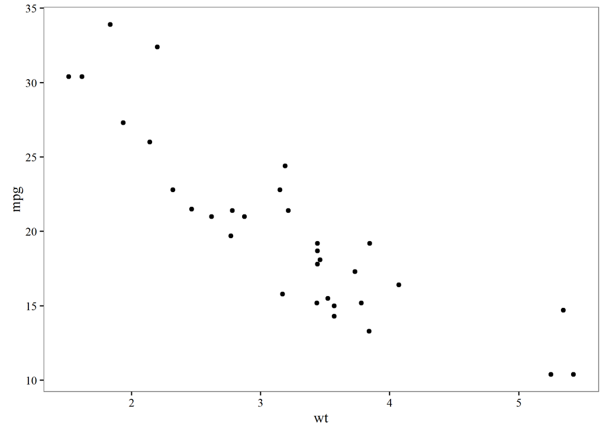

Fig 3. 12 pt Time New Roman font figure.

```r
ggplot(mtcars, aes(wt, mpg))+geom_point()+
  theme_bw(base_size=12,base_family='Times New Roman')+
  theme(panel.grid.major = element_blank(),panel.grid.minor = element_blank())
```

## 2.5 A better way: theme_set()

While all these adjustments to ggplot are great, there is a much better way for defining all of your ggfigures. It goes by the name theme set. Here is a working example.

First load the fonts

```r
library(extrafont);library(ggplot2)
#font_import() only do this one time - it takes a while
loadfonts(device="win")
windowsFonts(Times=windowsFont("TT Times New Roman"))
```

then use theme_set to determine the desired font and figure parameters.

```r
theme_set(theme_bw(base_size=12,base_family='Times New Roman')+
             theme(panel.grid.major = element_blank(),
                   panel.grid.minor = element_blank()))
```

With the basic figure options set, less time is spent coding figures and more time can be spent exploring data. The code used to produce Figure 3 is now reduced to:

```r
ggplot(mtcars, aes(wt, mpg))+geom_point()
```

# 3 Exploratory data analysis (very brief)

## 3.1 Smoothers

Lets explore these data, starting with a smooth. the base smooth for ggplot is *loess* (Figure 4) for data groups <1000 and a *gam* for groups >1000.

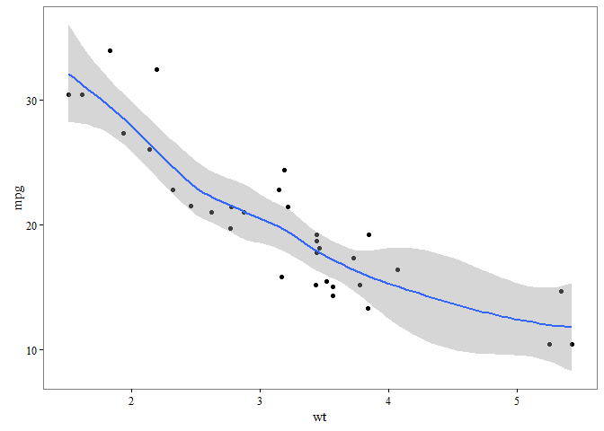

Fig 4. Loess smoother.

```r
ggplot(mtcars, aes(wt, mpg))+geom_point()+geom_smooth()
```

That is great and all but most of us do not use *loess* on a regular basis. However we can also implement other model structures (Figure 5).

In this case we added a linear regression (lm) and generalized linear regression with a polynomial (glm), a generalized additive model with knots (k) set at 5, and a non-linear least squares model. *Note that the polynomial in the glm smooth could also be done via the lm smooth (also with the poly function instead of the identity component)*,  
however I’m mostly showing that their is a glm function that can be assigned different distributions (e.g., family=“binomial”), same goes for the gam smoother.

More info can be found here http://www.ats.ucla.edu/stat/r/faq/smooths.htm. Other good things can be found on that site as well.

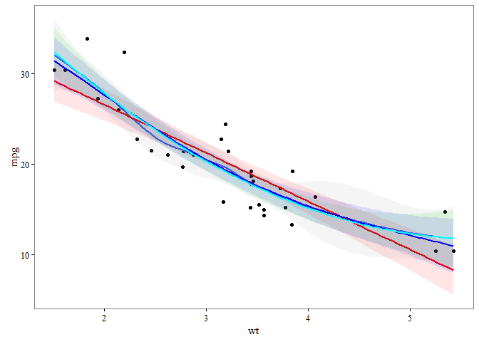

Fig 5. Multiple smoothers.

```r
ggplot(mtcars, aes(wt, mpg))+geom_point()+
   #loess smoother
   geom_smooth(alpha=.1)+
   #linear model
   geom_smooth(method='lm',alpha=.1, color=2, fill=2)+
   #generalized linear model
   geom_smooth(method='glm', alpha=.1, color=3, fill=3, formula=y~x+I(x^2))+
   #generalized additive model
   geom_smooth(method='gam', alpha=.1, color=4, fill=4, formula=y~s(x, k=5))+
   #non-linear least squares
   geom_smooth(method = "nls", formula = y ~ a*x^2 + b*x +c,
               method.args=list(start=list(a=.1,b=.5,c=.2)), se = FALSE, linetype = 1,
               colour = 5, fill=5, alpha=.1)
```

# 4. Plot options

## 4.1 Point size & color

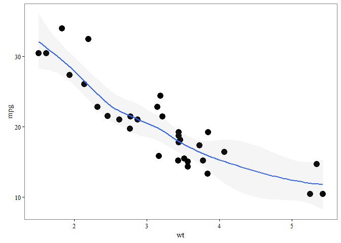

Figure 6. Point size.

```r
ggplot(mtcars, aes(wt, mpg))+geom_point(size=4)+geom_smooth(alpha=.1)
```

However, if you want the points to be different colors this can be added to the aesthetic component (in either the `ggplot()` or `geom_point()` component). For example lets change the size and color of the points by a car’s horsepower (hp) a continuous variable in the dataframe.

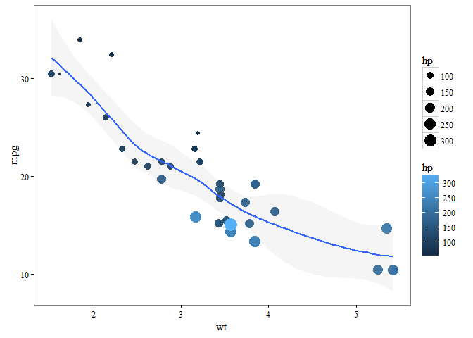

Figure 7. Continuous horsepower for color and size.

```r
ggplot(mtcars, aes(wt, mpg))+geom_point(aes(size=hp, color=hp))+
  geom_smooth(alpha=.1)
```

The colors and sizes could also be determined by changing hp to a factor.

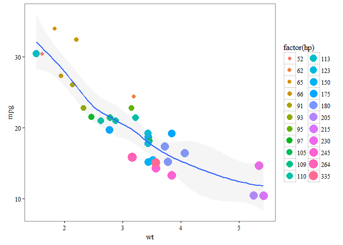

Figure 8. Factored horse power for point color and size.

```r
ggplot(mtcars, aes(wt, mpg))+geom_point(aes(size=factor(hp), color=factor(hp)))+
  geom_smooth(alpha=.1)
```

However this will often create too many discrete groups to clearly understand what is being plotted, therefore a “better” method is to define the scales for the data points. This can be done with `scale_color_gradientn()`.

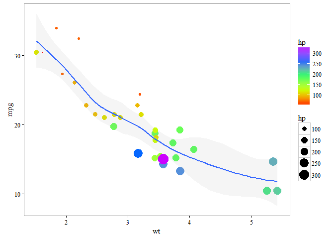

Figure 9. Continuous horsepower color gradient.

```r
ggplot(mtcars, aes(wt, mpg))+geom_point(aes(size=hp, color=hp))+
  geom_smooth(alpha=.1)+
  scale_colour_gradientn(colours=rainbow(5))+
  scale_size(range=c(0,7))
```

Want to define where the legend breaks? no problem, just add a vector of values.

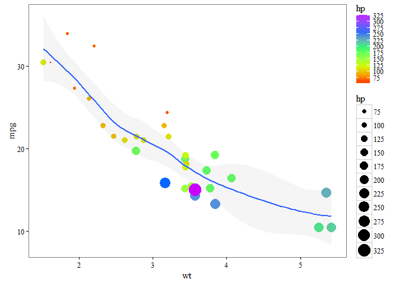

Figure 10. Continuous horsepower color gradient with defined breaks.

```r
bs <- seq(0,350,25) # define break locations
ggplot(mtcars, aes(wt, mpg))+geom_point(aes(size=hp, color=hp))+
  geom_smooth(alpha=.1)+
  scale_colour_gradientn(colours=rainbow(5), breaks=as.vector(bs))+
  scale_size(range=c(0,7),breaks=as.vector(bs))
```

Note that the legend may fall off the plotted area of the figure. One way to fix this is to remove one of the legends, in this case the legend that references the size of the points.

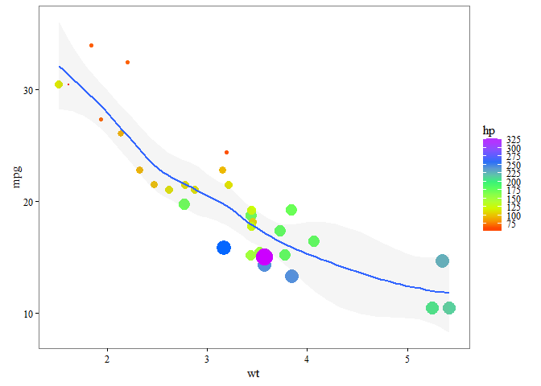

Figure 11. Continuous horsepower color gradient with defined breaks and one legend removed.

```r
ggplot(mtcars, aes(wt, mpg))+geom_point(aes(size=hp, color=hp))+
  geom_smooth(alpha=.1)+
  scale_colour_gradientn(colours=rainbow(5), breaks=as.vector(bs))+
  scale_size(range=c(0,7), breaks=as.vector(bs),guide = FALSE)
```

The legend now breaks in increments of 25 using a 5 color scale from the rainbow color palette.

## 4.2 Axis tickmarks

It is quite easy to change the axis tick marks. Change the y-axis to every 5th value.

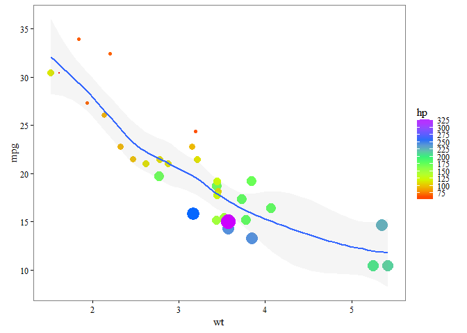

Figure 12. Change y-axis tick marks.

```r
ggplot(mtcars, aes(wt, mpg))+geom_point(aes(size=hp, color=hp))+
  geom_smooth(alpha=.1)+
  scale_colour_gradientn(colours=rainbow(5), breaks=as.vector(bs))+
  scale_size(range=c(0,7), breaks=as.vector(bs),guide = FALSE)+
  scale_y_continuous(breaks= seq(0,40,5))
```

Also change the x-axis, this time to unequal spacings.

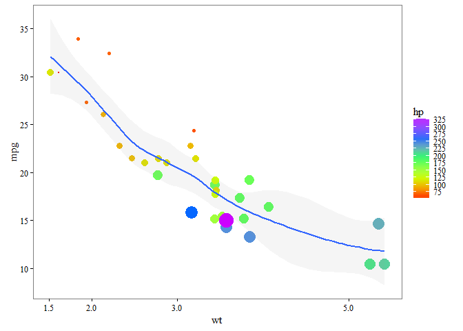

Figure 13.Change y-axis and x-axis tick marks.

```r
ggplot(mtcars, aes(wt, mpg))+geom_point(aes(size=hp, color=hp))+
  geom_smooth(alpha=.1)+
  scale_colour_gradientn(colours=rainbow(5), breaks=as.vector(bs))+
  scale_size(range=c(0,7), breaks=as.vector(bs),guide = FALSE)+
  scale_y_continuous(breaks= seq(0,40,5))+
  scale_x_continuous(breaks= c(0,1,1.5,2,3,5))
```

Your collaborator really prefers to have all of the tick marks present so… Change the labels while keeping the tickmarks.

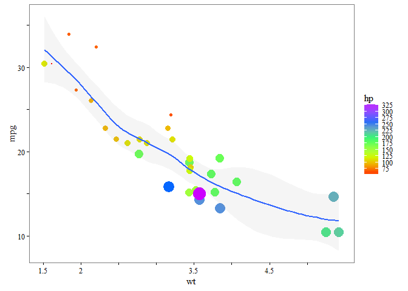

Figure 14.Change y-axis and x-axis tick marks.

```r
ggplot(mtcars, aes(wt, mpg))+geom_point(aes(size=hp, color=hp))+
  geom_smooth(alpha=.1)+
  scale_colour_gradientn(colours=rainbow(5), breaks=as.vector(bs))+
  scale_size(range=c(0,7), breaks=as.vector(bs),guide = FALSE)+
  scale_y_continuous(breaks= seq(0,40,5), labels=c(0,"",10,"",20,"",30,"",40))+
  scale_x_continuous(breaks= seq(0,5,.5), labels=c(seq(0,2,.5),"","",3.5, "",4.5,""))
```

However, the scale presented doesn’t include zero, something that is often nice to have. The standard way to do this is to use xlim() and/or ylim().

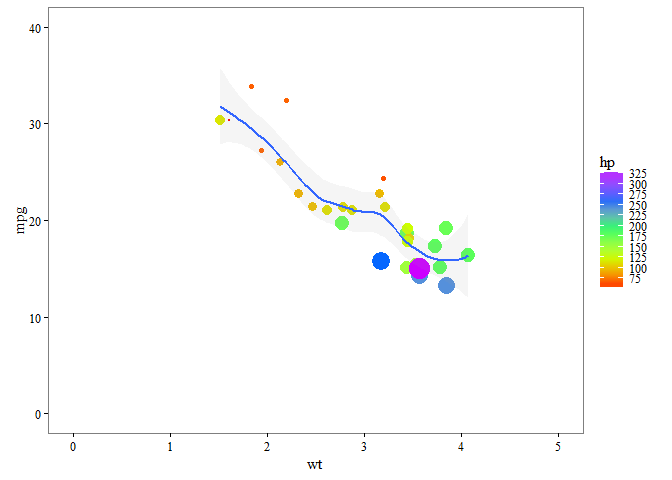

Figure 15. Change y-axis and x-axis tick marks.

```r
ggplot(mtcars, aes(wt, mpg))+geom_point(aes(size=hp, color=hp))+
  geom_smooth(alpha=.1)+
  scale_colour_gradientn(colours=rainbow(5), breaks=as.vector(bs))+
  scale_size(range=c(0,7), breaks=as.vector(bs),guide = FALSE)+
  xlim(0,5)+ylim(0,40)
```

A number of things have now changed

- 1. the scales have reverted back to their original designations,
- 2. zero is now included on both axes, and
- 3. we have cut off data by constraining the axis at 5.

One function of ggplot is that it only evaluates the data that is in the figure pane. So any smooths, etc., are informed only by the data that is seen. This can be changed to include the data that inform a smooth, but allow the figure to be “zoomed in” on an area of interest. To do this we use`coord_cartesian()`.

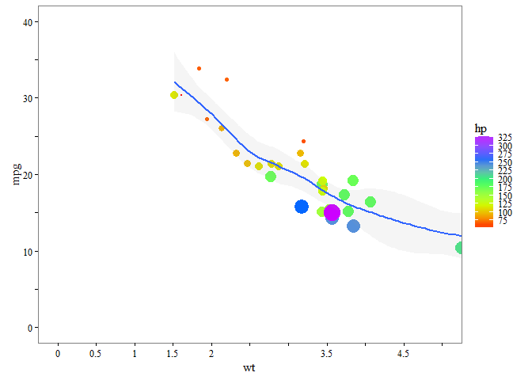

Figure 16. Using coord_cartesian to “zoom in”.

```r
ggplot(mtcars, aes(wt, mpg))+
  geom_point(aes(size=hp, color=hp))+
  geom_smooth(alpha=.1)+
  scale_colour_gradientn(colours=rainbow(5), breaks=as.vector(bs))+
  scale_size(range=c(0,7), breaks=as.vector(bs),guide = FALSE)+
  scale_y_continuous(breaks= seq(0,40,5), labels=c(0,"",10,"",20,"",30,"",40))+
  scale_x_continuous(breaks= seq(0,5,.5), labels=c(seq(0,2,.5),"","",3.5, "",4.5,""))+
  coord_cartesian(xlim=c(0,5),ylim=c(0,40))
```

The smooth now extends to the end of the pane as it indeed includes the values that are off the page. The points can be brought back into the figure by changing the x-axis limits.

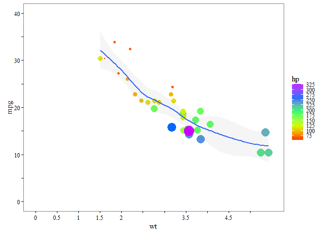

```r
ggplot(mtcars, aes(wt, mpg))+
  geom_point(aes(size=hp, color=hp))+
  geom_smooth(alpha=.1)+
  scale_colour_gradientn(colours=rainbow(5), breaks=as.vector(bs))+
  scale_size(range=c(0,7), breaks=as.vector(bs),guide = FALSE)+
  scale_y_continuous(breaks= seq(0,40,5), labels=c(0,"",10,"",20,"",30,"",40))+
  scale_x_continuous(breaks= seq(0,5,.5), labels=c(seq(0,2,.5),"","",3.5, "",4.5,""))+
  coord_cartesian(xlim=c(0,5.5),ylim=c(0,40))
```

# 5 Maps

## 5.3 Bathymetry - In progress…

```r
library(marmap)

#  Download data from the server
getNOAA.bathy(lon1=-175,lon2=-156,lat1=53,lat2=66, resolution=1) -> AKBath
#  Plot bathy data
plot(AKBath, image=T,xlim=c(-175,-156), ylim=c(53,66),las=1)
#  Ghetto low res AK map
map('worldHires',fill=T,xlim=c(-175,-156), ylim=c(53,66),add=T, col=8)
# Scale bar
scaleBathy(AKBath, deg=2, x="topleft", inset=5)
```